# Trabajo Final

#### Diplomatura de Diplomatura de Especialización en Ciencia de Datos para las Ciencias Sociales y la Gestión Pública 2021-01

**ÍNDICE**

1. Planteamiento del problema e hipótesis
2. Selección de bases de datos
3. Análisis
4. Bibliografía

### **1. Planteamiento del problema e hipótesis**

**Problema de investigación:** El temor al crimen en las áreas urbanas del Perú

**Pregunta de investigación:** ¿Cómo ha evolucionado el temor al crimen en las áreas urbanas del Perú durante los últimos años?

**Hipótesis General:** El temor el crimen se ha mantenido casi constante durante los últimos años.

**Hipótesis específica 1:** El temor al crimen se da forma diferencia por sexo.

**Hipótesis específica 2:** El temor al crimen se da forma diferencia entre las regiones naturales (Costa, Sierra y Selva).

### **2. Selección de bases de datos**

Se emplerá la Encuesta Nacional de Programas Presupuestales (ENAPRES) del INEI. El capítulo de interés de esta encuesta para la presente investigación es el denominado “Seguridad Ciudadana”. Este capítulo contiene preguntas dirigidas exclusivamente a las personas que viven en el área urbana y que tienen de 14 años a más de edad. Se emplerán las bases de datos para los años del 2017 al 2020.

### **3. Análisis**

**3.1 COMPONENTE EMOCIONAL**

Para evaluar este componente, se utilizará la siguiente pregunta del ENAPRES:

“Cuando usted camina de noche en su zona o barrio, ¿se siente…?”

La variable toma 4 valores:

1- Muy inseguro 2- Inseguro 3- Seguro 4- Muy seguro

Transformamos dicha variable para que sea una dicotómica.

**Tabla 1**

Se reporta el porcentaje de personas que siente inseguridad al caminar de noche según año. Según se observa, alrededor de la mitad de los encuestados, sienten inseguridad al caminar de noche para los distintos años.

| Año | Inseguridad noche | Total | Porc |
| --- | --- | --- | --- |
| 2017 | Inseguridad | 34571 | 50.73 |
| 2017 | Seguridad | 33576 | 49.27 |
| 2018 | Inseguridad | 35827 | 51.69 |
| 2018 | Seguridad | 33489 | 48.31 |
| 2019 | Inseguridad | 35643 | 51.70 |
| 2019 | Seguridad | 33296 | 48.30 |
| 2020 | Inseguridad | 17675 | 51.52 |
| 2020 | Seguridad | 16631 | 48.48 |

**Gráfico 1**

Se observa poca variación en los años. Esto indicaría que en realidad la inseguridad en cuanto a caminar de noche sigue siendo la misma año tras año.

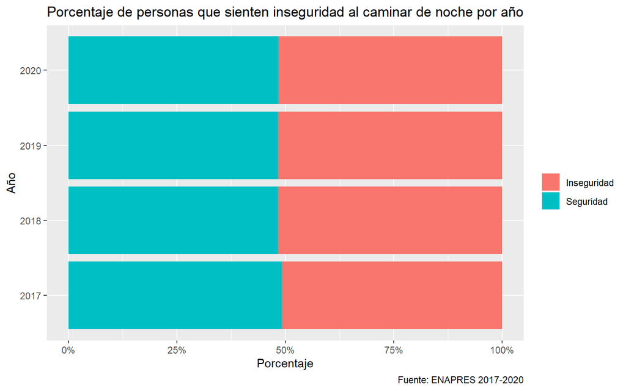

**Tabla 2**

Se reporta el porcentaje de personas que siente inseguridad al caminar de noche según región natural y sexo.

| Región natural | Sexo | Inseguridad noche | Total | Porc |
| --- | --- | --- | --- | --- |
| Costa | Hombre | Inseguridad | 26364 | 50.16 |
| Costa | Hombre | Seguridad | 26197 | 49.84 |
| Costa | Mujer | Inseguridad | 35150 | 59.56 |
| Costa | Mujer | Seguridad | 23870 | 40.44 |
| Sierra | Hombre | Inseguridad | 17678 | 46.86 |
| Sierra | Hombre | Seguridad | 20048 | 53.14 |
| Sierra | Mujer | Inseguridad | 23800 | 54.55 |
| Sierra | Mujer | Seguridad | 19829 | 45.45 |
| Selva | Hombre | Inseguridad | 9042 | 39.11 |
| Selva | Hombre | Seguridad | 14076 | 60.89 |
| Selva | Mujer | Inseguridad | 11682 | 47.38 |
| Selva | Mujer | Seguridad | 12972 | 52.62 |

**Gráfico 2**

Se observa que las mujeres presentan mayor inseguridad que los hombres en todas las regiones naturales. Además, en la costa, se observa mayor inseguridad tanto en hombres como mujeres en relación a las otras regiones.

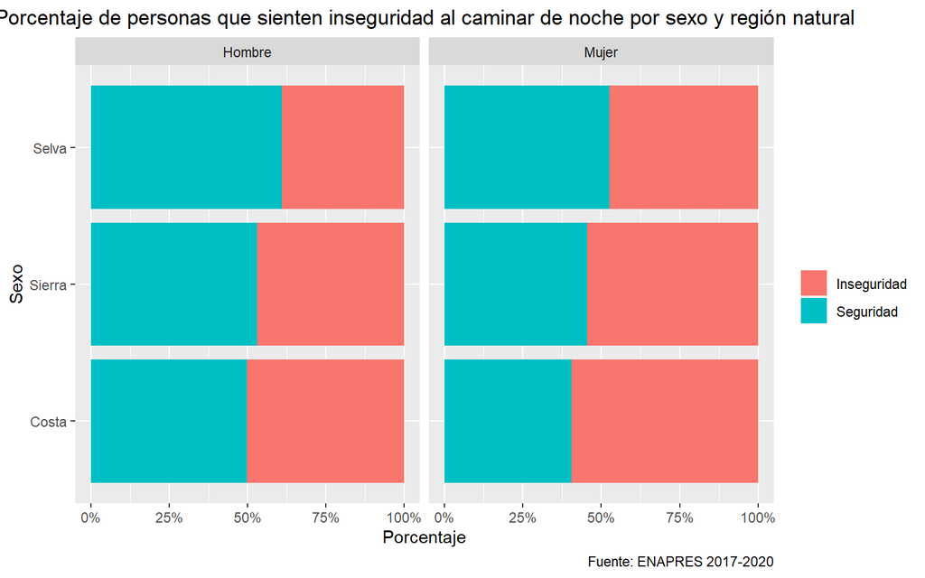

**3.2 COMPONENTE DE COMPORTAMIENTO**

Para evaluar este componente, se utilizarán las siguientes preguntas del ENAPRES:

“Usted ¿ha dejado o evita [determinada acción]*, por temor a ser víctima de la delincuencia?”

Las variables tienen 3 valores:

1- sí 2- no 3- no sabe

Creamos una variable llamada “Inseguridad” que tome el valor de 1 si es que la persona, al menos, ha dejado o evitado de realizar determinada acción.

*Son en total 6 acciones: salir de noche, salir a caminar, contestar el celular en la calle, llegar muy tarde a casa, tomar taxi en la calle y llevar mucho dinero en efectivo.

**Tabla 3**

Se presenta una tabla con el porcentaje de personas que al menos al dicho que sí han dejado de realizar alguna de las acciones por miedo a la delincuencia según año. En el 2017, se observa el mayor porcentaje (52.52%)

| Año | Inseguridad | Total | Porc |
| --- | --- | --- | --- |
| 2017 | No | 32185 | 47.48 |
| 2017 | Sí | 35606 | 52.52 |
| 2018 | No | 34670 | 50.29 |
| 2018 | Sí | 34276 | 49.71 |
| 2019 | No | 33399 | 48.66 |
| 2019 | Sí | 35233 | 51.34 |
| 2020 | No | 16543 | 48.50 |
| 2020 | Sí | 17569 | 51.50 |

**Gráfico 3**

Se observa que los porcentajes no han variado mucho durante los años.

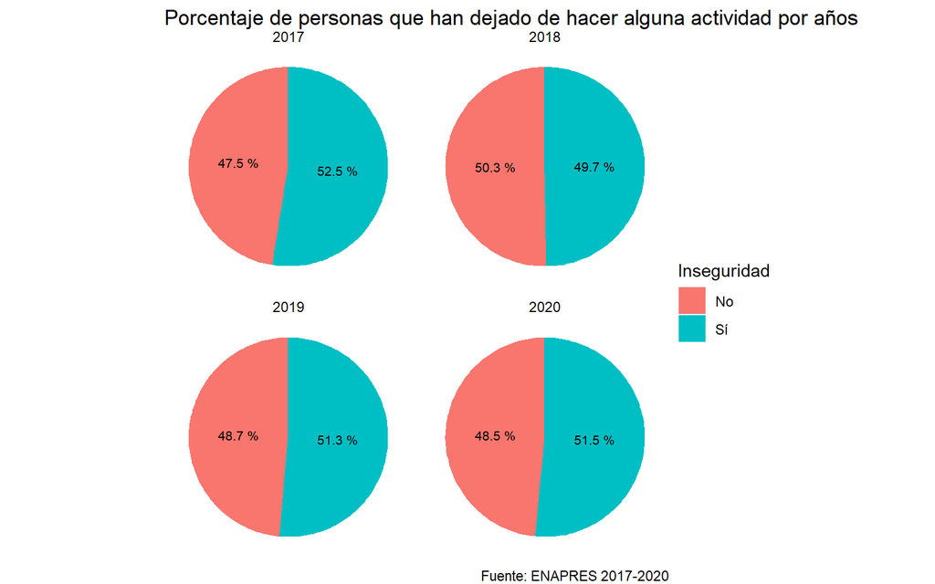

**Tabla 4**

Se presenta una tabla con el porcentaje de personas que han dejado de realizar alguna actividad por temor a la delincuencia según región natural y sexo.

| Región | Sexo | Inseguridad | Total | Porc |
| --- | --- | --- | --- | --- |
| Costa | Hombre | No | 25381 | 48.58 |
| Costa | Hombre | Sí | 26869 | 51.42 |
| Costa | Mujer | No | 22958 | 39.17 |
| Costa | Mujer | Sí | 35655 | 60.83 |
| Sierra | Hombre | No | 20344 | 54.12 |
| Sierra | Hombre | Sí | 17246 | 45.88 |
| Sierra | Mujer | No | 21844 | 50.26 |
| Sierra | Mujer | Sí | 21620 | 49.74 |
| Selva | Hombre | No | 13526 | 58.76 |
| Selva | Hombre | Sí | 9495 | 41.24 |
| Selva | Mujer | No | 12744 | 51.93 |
| Selva | Mujer | Sí | 11799 | 48.07 |

**Gráfico 4**

Se observa que las mujeres en la costa son las que presentan el porcentaje más alto de dejar de realizar alguna actividad por temor a la delincuencia (60.8%).

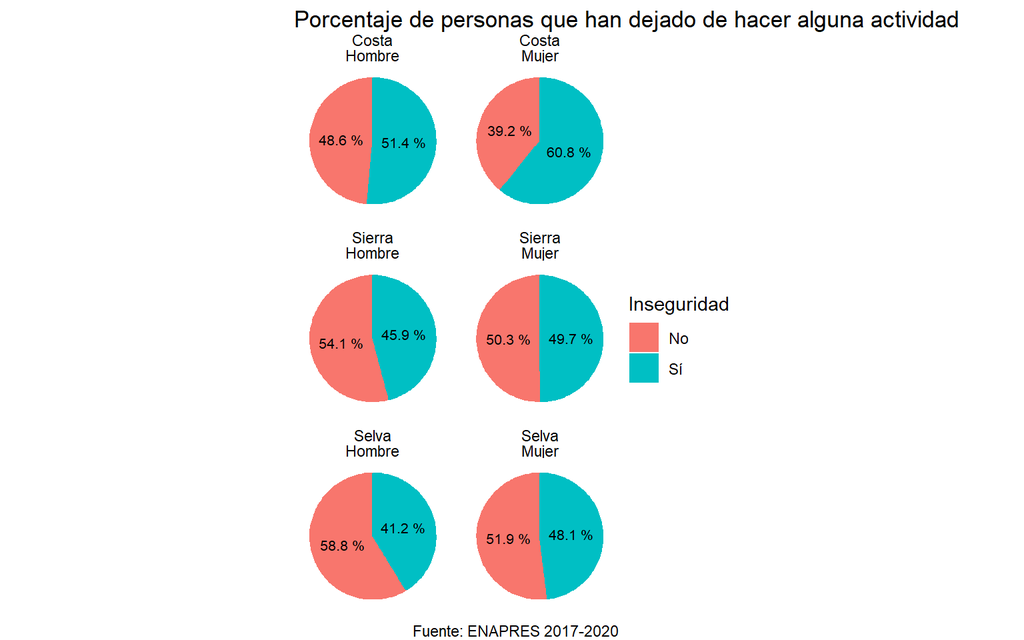

**3.3 COMPONENTE COGNITIVO**

Para evaluar este componente, se utilizarán la siguientes preguntas del ENAPRES:

“En los próximos 12 meses, ¿Usted cree que puede ser víctima de [determinado hecho delictivo]*?

La variable toma 3 valores:

1- Sí 2- No 3- No tiene

Lo que realizaremos es un índice de percepción de inseguridad per cápita. La fórmula empleada para la elaboración del índice de percepción de inseguridad per cápita es el siguiente:

$$(1/N)\sum_{n=0}^{13} i*N_i$$

donde:

$N_i$ es la cantidad de individuos que ha sido víctimas de “$i$” delitos $N$ es el número total de individuos

*Se consideran 13 hechos delictivos: robo de vivienda, robo de vehículo automotor, robo de autopartes del vehículo automotor, robo de motocicleta/mototaxi, robo de bicicleta, robo de dinero/cartera/celular, amenazas/intimidaciones, maltrato físico/psicológico en el hogar, ofensas sexuales, secuestro, extorsión, estafa y robo de negocio.

**Gráfico 5**

Se observa que el índice de percepción de inseguridad per cápita, si bien no ha variado mucho, presenta su menor valor para el 2020. En específico para dicho año, en promedio, una personas ha reportado que percibe que puede ser víctima de 3.12 hechos delictivos durante los 12 próximos meses.

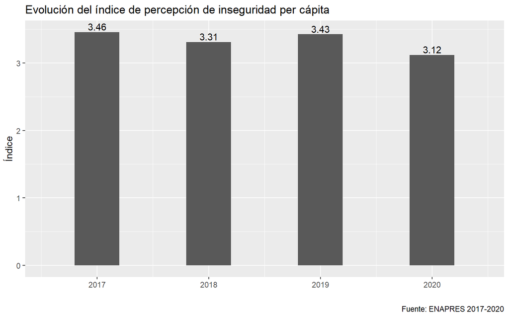

**Gráfico 6**

Se observa que los hombres perciben mayor percepción de inseguridad que las mujeres para todos los años.

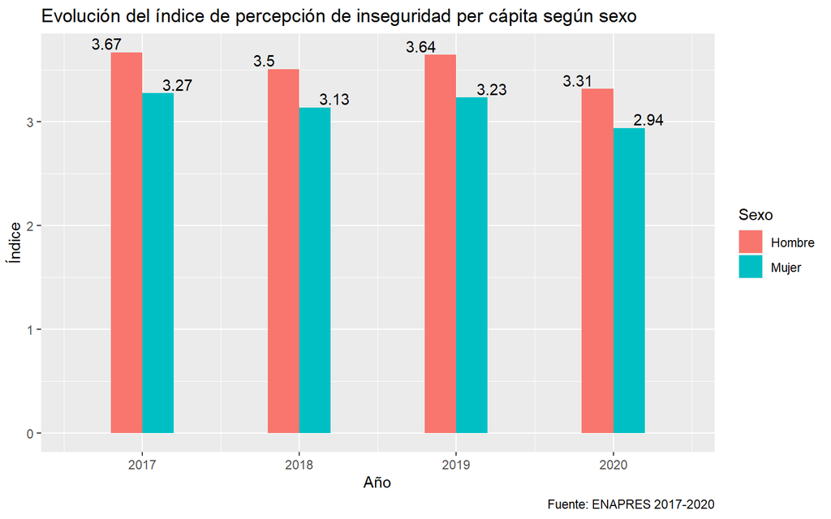

### **4. Bibliografía**

Clément, M., & Piaser, L. (2021). Do inequalities predict fear of crime? Empirical evidence from Mexico. World Development, 140, 105354.